# Final Report for California and Louisiana

Asher Aley, Wendy Arenas, Ximena Juarez, Shadman Shahzahan

# Abstract

This report examines congressional redistricting in California and Louisiana by focusing on political fairness, minority representation, compactness, and voter engagement. Our initiative examines how district lines can impact election results and determine the fairness of community representation. Utilizing information from the Redistricting Data Hub, our team analyzed congressional district lines, 2024 election outcomes, voter turnout statistics, Citizen Voting Age Population data, and demographic trends for both states. We created an interactive Streamlit dashboard called DistrictLens that enables users to navigate maps of California and Louisiana, compare proposed plans, examine district-level results, and visually assess fairness metrics.

In our analysis of California, we examined the political context surrounding Proposition 50 and aimed to establish additional Democratic-leaning districts. We contrasted aggressively gerrymandered maps with more equitable maps created via redistricting simulations. The equitable California map emphasized population balance, compactness, and minority representation, though it did not fully achieve the political objective of reducing Republican districts. Our results indicated that young voter turnout is significant, as youth engagement varied across districts. Certain regions experienced higher participation rates among young voters, whereas others had a significant number of registered young voters who chose not to vote, potentially influencing future election results.

In Louisiana, our initiative concentrated on the state’s background of racial gerrymandering and the difficulty of designing compact districts that simultaneously safeguard minority voting rights. Louisiana’s suggested fair map enhanced compactness and reduced extreme minority packing compared to the 2020 map. Nonetheless, establishing multiple Democratic-leaning districts without significant gerrymandering proved challenging due to variations in voter distribution and participation rates.

Ultimately, this project demonstrates that redistricting involves more than simply creating borders. It requires balancing population equality, compactness, competitiveness, partisan outcomes, minority representation, and voter engagement. Using both written analysis and the DistrictLens dashboard, our project shows how data visualization can simplify the understanding and evaluation of redistricting decisions.

# Introduction

Every 10 years, electoral district boundaries are redrawn to reflect the constantly shifting and growing population and to ensure fair and equal representation. However, the new proposed redistricting plans may face legal challenges, forcing states to redraw their district boundaries mid-decade. Such was the case for the two states this report will be focusing on: California and Louisiana.

# California Redistricting

In 2025, Texas’s new congressional map sought to add up to 5 Republican districts to help Trump and the Grand Old Party (GOP) in the midterm elections(Common Cause California, 2026). To counteract these changes, California Governor Gavin Newsom proposed temporarily overriding the commission and creating districts more favorable to Democrats. In the end, voters approved California Proposition 50, a ballot measure that grants the state legislature the power to redraw California’s congressional map before the midterm, by 65% - 35% (Ballotpedia, 2026).

To better understand how redistricting could affect representation in California, our group analyzed voting and demographic data from the “2024 California L2 Voter File General Election Turnout Statistics Aggregated to 2020 Census Blocks”, obtained from the Redistricting Data Hub. The data set contained information on voter registration and turnout by party affiliation, age, gender, and race. One of the most important aspects of the data that made it meaningful for our group was the 15-digit census block code named “GEOID20” because it allowed our team to join the voter data with census population data from the PL94171 package. This connection allowed us to incorporate population information when evaluating potential redistricting plans. This connection enabled us to incorporate population information when evaluating potential redistricting plans.

During the data preparation process, we focused primarily on voter registration and turnout variables by age(18-89 years old), party affiliation (democratic & republican). While the dataset contained detailed racial categories, some were narrowly defined and represented relatively small populations. We also had access to broader demographic information through census data, we chose to emphasize those larger population groups (Hispanic, Black, Asian, White) in our analysis.

The census data for California from the PL94171 package, is the U.S Census Bureau’s data but it did not contain the geometries despite having a column where they were meant to be. So, we obtained the geometry/shapefiles from the Tigris package and joined it to our census data by the GEOID that matched, and it matched with our voting data as well, so we could have it all in one new clean useful dataset.

We began with our analysis focused on one of California’s largest populations, the Hispanic population, making up 40%. Based on our findings, we’ve identified that areas in Northern rural California had denser Hispanic communities that voted for the Republican Party. Looking into why Trump received more support from the Hispanic community in the last election, it turned out that personal reasons influenced this change in party decision. One such example is how some families experienced positive changes during Trump’s previous term in office.

[figure not shown]

Hispanic Democratic Turnout %

[figure not shown]

Hispanic Republican Turnout %

As a result, Trump won the last election because of major support from the Hispanic community. If California wants to secure more democratic districts, areas with Hispanic Republican voters would need to be split, or they could be split from other areas and put into a safe Republican district.

Another thing they would have to consider is the influence young voters could have on turnout. Young voters have the potential to influence election results, but their lower voter turnout may keep counties Republican that might otherwise shift Democratic if youth participation were higher. It could be because most people assume California will be a blue state no matter what, and that their vote won’t matter; however, that kind of thinking could lead to trouble.

### Methods

To create our redistricting plans, we used the redist package and specifically a Sequential Monte Carlo algorithm. However, before we could create the plans for California, we needed to reduce the number of observations significantly because without it the program would not run even after hours. Instead of having all the precincts down to the 15 digit code, we added a columns that only used 11 out of the 15 digits to create larger blocks of the areas, and then we could group by the 11 digit code, and it brought out observations to under 10,000 which was more reasonable and easier to work with. We then summarized the statistics we had such as total votes, total registered voters, the total votes/registration pertaining to democratic or republican or if it was male, female, or the specific age group, that way we kept all the variables and just summed the groups that fell into the same GEOID that was now 11 digits. This allowed us to create plans for California in a timelier manner. From there when we created the maps we used ratios such as the ratio of democratic and republican votes within a new district made and if it would make the district favor democrats or republicans based on the voting data it had from 2024, and then we added the scale to see the margin that the party won by. This allows for the visualization of the map to be easily read by someone looking briefly, the darker the blue the higher the margin for democrats and the darker the red the higher the margin for the republicans. Then once our redistricting plans were created, we explored how the CVAP was distributed among the districts to see if any power had been diluted among specific demographics such as the Hispanic community.

The SMC method was used to randomly generate a large number of possible redistricting plans that met our criteria. The specific criteria we were using in the algorithm was population within each district could not vary by more than 1%, and the compactness had to be as close as possible to 1. However, there were no weights assigned to compactness, while there certainly could have been because it might take compactness as a suggestion versus priority. So, what the Sequential Monte Carlo simulation does is randomly create plans, by one precinct at a time, using a restraint of population within each district, not varying by more than 1%, and the precincts have no adjacency/contiguity issues. It runs the number of simulations that you specify, and the number of runs you would like as well, so if you want 100 simulations and 2 runs, it would be 200 proposed plans. The underlying process is that it creates a large number of “particles” like parts of the plan that will then be mixed with other particles to make a full plan (Kantas, 2009). The particles represent partial redistricting plans; the simulation starts in one area and grows from there into a full plan. The particles need to have no contiguity issues or other problems with the geometry that would disrupt the process of attaching precincts together for districts. When adding precincts to the starting one, it focuses on the population balance instruction and makes sure the district is formed when all the particles (developing maps) meet the criteria. Then it continues to the next area and repeats the process, until the number of districts wanted(specified) have been formed. If criteria are not met or constraints are violated, the simulation does another resample, and those bad particles get dropped, and the good ones are kept. If particles are dropped, it is because it surpasses the population balance constraint, which is a hard constraint. Compactness is more of a soft constraint, and so if the maps are very low compared to other randomized maps, the particles can be dropped. If there are more specified constraints or specific weights, then the process would drop the particles if they do not reflect the most important criteria. The overall idea is that SMC makes a random redistricting plan from scratch, versus starting from an existing plan and adjusting the precincts into different districts. Although it seems to be common that even with 1,000s of maps created, the maps tend to look very similar because the SMC does what it can with the data provided, and extreme cases or changes would require some data manipulation or running 100,000 more runs to find a very different plan, which would be unlikely to occur fairly.

In a fun, simple way to grasp this information, think of playing a game of hide-and-seek with your eyes closed. Your friends are whistling from far away; your friends represent a proper map that meets the criteria you have specified. You try to move closer and can’t see your path, so you’re moving around, and then you hear other noises. Still, they are not your friends’ whistling, so that is not the right direction, and they have to be ignored. You are then moving closer to the proper path and staying in that area, while listening to the whistling get closer, and then finally you have found them. Then the process gets repeated with a new person, and the friends whistling are in a different area, and a new pathway is made, representing another plan.

To find the Polsby-Popper ratio and Reock ratio, the function of comp_polsby() and comp_reock() was used after the redist smc function to find the ratio for each district in each draw(map created), and then within each map created, found the average ratio for both Polsby and Reock , and arranged it highest to lowest in a different table/data frame to then find the best map in terms of compactness. Then from there checked if that map was able to hit other aspects of fairness in terms of population, minority representation, and party affiliation behavior. The Polsby Popper measure is calculated by “taking the ratio of the area of the district to the area of the circle whose circumference matches the perimeter of the district” and the Reock score is calculated by “taking the ratio of the area of the district to the area of the minimum circumscribing circle” (Redistricting Report Card Methodology | Gerrymandering Project, Princeton, 2023). The Polsby score is very sensitive to jagged boundaries, so it will produce a lower score even if the shape of the district isn’t as irregular but due to geographical characteristics of the state/boundaries, it can produce low polsby scores.

### Results

#### Adjacency Fix for California

California had 3 precincts that were disconnected from the others, and it were islands that were not connected to the mainland, so those were selected by their numbered row to be into a new data frame named bad precincts. Then, a function was made to add adjacency, to create a connection with one row to the next row, and one was subtracted from the adjacency list of those precincts that were disconnected to make them zero-indexed because the other contiguous precincts were zero-indexed as well. Then, the distances from the precinct to other precincts were computed, then the shortest nonzero distance to another precinct was found and saved. After, a connection between input precinct and closest to another precinct was added. This function then was used for every precinct found in the bad precinct data frame. These adjacencies were fixed and added back to the adjacency list to redistrict California.

#### California Extreme Gerrymander Map

In order to create a map that reached the political goals of California, which were to gain more democratic seats to counter off Texas’ new republican redistricts, we had to break apart the state into sections. The 3 sections of California were the norther area, district 1-22, Central California districts 23-37, and Socal districts 38-53. This selection of districts was made with filtering existing districts from census data of California from 2020 and therefore using the geometries of those selected district to remap new boundaries still with population deviation of 1% and compactness in mind. With the northern part of California, 10 districts were mapped, Central had 19 remapped districts, and Socal had 23 districts mapped, and the number of districts that we chose to create using the redist_map function were carefully chosen as they provided the most extreme gerrymandering results where there was 0-3 republican districts, and the best map to represent the political agenda made 4 republican districts. Within each section, there was lots of grouping and summarizing that needed to be done to get the voting information as well, to know the strength of the favorable party in each district. Which was taken by subtracting the total of the Democratic Party by the Republican and then dividing by the total, and then creating margin bins where if the percentage was in a certain range then it would coincide with the text of that margin and be used with the color scale to portray a clear story and legend. Once the individual maps were made, their rows were combined into a new data frame and then mapped with the same scale and labels that had been used to have a full new proposed map of California with extreme gerrymandering.

#### Fair California Map

The map created for California with the criteria of compactness as close as possible to 1, could only create 9-12 republican districts in 55,000 simulations. This may not help the agenda of reducing republican seats, but it is fairer in terms of compactness. The highest average Polsby-Popper score for a California map according to our simulation plans is .1968 and the highest average Reock score is .3978. Our team picked the map with the higher score of the two which was the Reock Score. This map created 10 republican districts, and 36 majority minority districts and only 5 of those were republican favoring. In terms of fairness, it gives representation to minority groups, it does its best in terms of compactness, it does have the population balance (Reock score), that each district doesn’t vary by more than 1%. There is some packing because visually there is irregular, elongated shapes. There is some packing because visually there is irregular, elongated shapes, but the fair proposed map of ours has 23 districts with over 60% of the minority VAP while the 2020 map had 25 districts and therefore suggest that packing was not done but rather an improvement. There are in our current proposed map 3 districts with under 30% of the minority VAP, which is the same amount as the 2020 California map had with that characteristic, so it shows there was no further voting power dilution (Redistricting, 2023).

We picked this map with the higher average Reock score because it gave a more favorable compactness score, and not one metric is the best one for compactness, and this map represented more acceptable fairness metrics. Also, the Reock score for the 2020 California map was averaged .341 so this new map is an improvement in terms of compactness because it is .0568 greater (16% increase). This calculation was made from determining the Reock score of each district of California from 2020 from the alarm data/census and then the average of all of them combined.

There are 7 competitive districts with a winning margin 0-5%, and this isn’t necessarily showing fairness, but in a way can be seen as communities of interest being kept together. Although it could be improved so people feel like their vote makes a difference. Overall, this map shows an improvement from the 2020 map in terms of fairness because it touches upon more than just a political agenda.

# Louisiana Redistricting

Louisiana’s congressional redistricting in the 2020’s have so far been centered around racial gerrymandering. Louisiana’s 2020 congressional districts had 5 republican districts and 1 democratic district. However, to avoid being sued for diluting black voting power, Louisiana proposed a redistricting plan in 2022, because a third of Louisiana’s population is black. So, it had 4 republican districts and 2 democratic districts, with both democratic districts being majority minority. With the ruling of Louisiana v. Callais in 2026, Louisiana proposed a plan yet again due to racially gerrymandering, and this plan was passed into law. Louisiana’s new districts are similar to its 2020 districts. Both democratic districts from the 2020 and 2026 districts pack black voters, diluting black voting power. These districts pack black voters by drawing lines around black neighborhoods in New Orleans and Baton Rouge. The 2022 proposed plan had a second majority-minority district span that was thin, but it also spanned over half of the state. This district also packed black neighborhoods, but it had to do so from across the entire state.

#### Supreme Court case.

Louisiana v. Callais was ruled April 29th, 2026, and Louisiana’s 2022 proposed congressional districts were deemed to be unconstitutional due to racial gerrymander. This ruling also impacted the integrity of the Voting Rights Act, as the Supreme Court found using predominantly race to redistrict to be a form of gerrymandering.

This may have been the case in Louisiana, as the 2022 proposed map required packing that resulted in a thin district that spanned over half the length of Louisiana. However, Louisiana’s one democratic district is not any better. The district, even in 2026, still packs black neighborhoods by splitting cities multiple cities apart. If redistricting plans cannot be decided by race, then Louisiana is still gerrymandering.

### Methods

Because Louisiana has a history of drawing noncompact districts to control demographics, we decided to redistrict to do the opposite. Our first step in redistricting was to keep precincts within their parishes, and to group certain parishes together that shared the same cities (e.g. Caddo and Bossier parishes). Then, we generated 55,000 maps and picked the map with the highest average Reock compactness index across all districts. From that map, we moved precincts around for fine tuning. The function we used prioritized preserving equal population across all districts, which causes district lines to cross parish borders, so we moved district lines to avoid crossing through parishes. District 6 required more manipulation. We initially wanted a second democratic district to reflect the third of the votes going toward the democratic, but this requires extreme gerrymandering. To compensate, we made district 6 a competitive district with republicans having the majority by 3.7%. District 6 includes the Baton Rouge area, and other areas that allow its partisan lean to be within 5%. Finally, some district lines were moved to cross through parish borders, so that populations within each district would deviate by less than 1%.

### Results

Roughly half of the registered voters are republican, and the other half are democrats. However, there are slightly more registered democrats than republicans, yet Louisiana is a very republican state. The two largest voter demographics in Louisiana in 2024 are white republicans with roughly 800,000 registered voters and black democrats with roughly 700,000 registered voters. However, the republican lean comes from voter turnout, in which 63% of black democrats voted compared to 81% of white republicans. Voter turnout can be significantly impacted by gerrymandering. If districts are drawn so that a certain favorable outcome is more guaranteed, then voters won’t feel like their vote matters.

## Goals and Attainment

Louisiana cannot, with voting data, have more than one democratic district without extreme gerrymandering, so that goal is not attainable. We made a map with one district, which is what they had to begin with. Another goal was to try not to dilute voting power for minorities, but based on geographical constraints, our plan only had one minority majority district, which is only 1/6 of the districts, when at least the Black demographic makes up 1/3 of the population in the state. Yet, it is due to the location of where the groups are that some are concentrated and others are dispersed. However, compared to the 2020 map from Louisiana, there is better minority representation because all the districts have at least 30% of the minority VAP. So, we did create a map that met the goal about not diluting minority votes from this approach of all districts at least at 30% or higher of the minority VAP, and there is an improvement of the packing because the majority minority district is not over 60% of the minority VAP but rather 52%, and compared to the 2020 map, it is an improvement as well.

# DistrictLens - Interactive App

[DistrictLens](https://districtlens.streamlit.app/)

Our project includes an interactive redistricting map dashboard called DistrictLens, built with Streamlit and Python. The main purpose of DistrictLens is to help users explore congressional district plans for California and Louisiana in a more visual and interactive way. Instead of just showing screenshots or static maps, our dashboard lets users zoom in, pan across the state, switch between map layers, inspect individual districts, and compare political and demographic outcomes. This makes the project easier to understand because users can actually interact with the maps and see how district boundaries connect to real election, turnout, and demographic data.

The interactive map loads district boundary files, election results, voter turnout data, and demographic information. The app uses geographic data to draw each congressional district on the map, then connects those district shapes to statistics such as Democratic vote share, Republican vote share, total votes, turnout rate, minority Citizen Voting Age Population, young voter turnout, compactness, and competitiveness. Users can choose whether to view California or Louisiana, and which map or layer to analyze. Once a layer is selected, the colors on the map update based on the metric being shown. For example, a district with a higher Democratic vote share may look different from one with a higher Republican vote share. This helps users quickly recognize patterns across the state.

One important part of our project was including both reference/original maps and final proposed maps. For California, the dashboard first shows the original proposed California map, and then it shows the final California map, the Final California Proposed Plan. For Louisiana, the dashboard first shows the original Louisiana map, Proposed Redistricting for Louisiana with Partisan Lean, and then the final Louisiana map, Final Proposed Louisiana Plan. This setup allows users to compare earlier versions of the maps with the final versions. By embedding each map directly in the Streamlit app as an interactive HTML file, users can still zoom, pan, and inspect districts rather than just viewing a flat image.

Part of our project focused heavily on making the interactive map dashboard more useful and understandable for users. We worked on connecting the map visuals to the fairness metrics and making sure the dashboard did more than just display boundaries. We wanted the map to help explain the impact of redistricting decisions. This included helping organize the California and Louisiana sections, ensuring the final maps were embedded correctly, and working on comparison tools that show how each state and each district performs. We also focused on making the dashboard easier to present, so that someone who does not know much about redistricting can still understand what the data is showing.

A major feature of the dashboard is the fairness metrics section. These metrics are important because every map should be evaluated separately. The original and final maps should not share the same score, as they may differ in district shapes, vote distributions, and demographic outcomes. In our dashboard, each map has its own metric table based on the data inside that specific plan. The fairness metrics include population balance, partisan outcome, competitiveness, packing and cracking proxy, majority-minority voting-age population, compactness, and contiguity. These categories help explain whether a district plan is balanced, whether districts are competitive, whether communities are being split apart or concentrated, and whether minority groups have realistic opportunities for representation.

Another important part of our project was including young voter turnout. This was something we worked on earlier in the project, and it became an important layer because redistricting not only affects party outcomes but also different groups of voters. Young voters are often underrepresented in political participation, so showing where registered young voters live and how many actually vote helps explain participation patterns across districts. In the dashboard, young voter turnout can be used to compare districts and see where youth participation is stronger or weaker. This adds another level to the analysis by showing that redistricting is not just about district shapes or party control. It is also about which communities are being represented and whether certain groups have meaningful political influence.

The dashboard also includes a district scorecard. This feature lets a user select a district and view a summary of key information, including the predicted winner, Democratic and Republican vote totals, margin of victory, turnout, minority CVAP share, young voter turnout, and competitiveness rank. This makes the map more useful because users do not have to look through raw data tables to understand each district. Instead, they can click or select a district and immediately see the most important information. The scorecard helps connect the visual map to the data behind it.

The California versus Louisiana comparison section is also an important part of the project. Since California and Louisiana have different political geography, population patterns, and district structures, comparing them side by side helps users understand how redistricting can look different across states. California has a much larger population and more districts, so the data is heavier and more difficult to process. Louisiana has fewer congressional districts, yet it still shows important patterns in partisan outcomes, minority representation, and district shape. By placing both states on the same dashboard, DistrictLens allows users to compare how fairness metrics perform across two different redistricting contexts.

Overall, DistrictLens is designed to make redistricting analysis easier to understand through interaction, visuals, and data. The project combines maps, election results, turnout statistics, demographic data, and fairness metrics into one dashboard. Our contribution helped turn the project from just a map into a tool that explains district outcomes and allows users to explore the political and representational impact of each plan. The final result is a dashboard that lets users move from viewing district boundaries to understanding what those boundaries mean for voters, competitiveness, minority representation, and young voter participation.

# Discussion

With Louisiana’s registered voters’ data, one can see there are more democratic registered voters than republican voters, but they are not the majority when it comes to elections, and this indicates that democrats are not voting. If democrats started to vote, they would probably make a difference, and then Louisiana might not have 5 republican districts, but 2 or 3 districts instead. We think there could be more campaigning in Louisiana to democrats that they can make a difference if they vote. One challenge with campaigning for democrats to vote more often, however, is that Louisiana is racially gerrymandered. A majority of democrats in Louisiana are minorities, and their vote gets wasted when they are packed into one district. Our goal of wanting to make a fair map for both states were done to the best of our ability with hard measures, such as compactness and minority representations, but other factors, like competitiveness, were harder to attain. Competitiveness allows for fewer wasted votes, because the partisan lean margin is very small. In order to win in a competitive election, a candidate would have to appeal to both sides in order to win. However, partisan lean is often heavily skewed in favor of the incumbent in an election. On top of this, geographical communities may vote similarly, so creating a competitive district could involve gerrymandering.

California’s Proposition 50 map was created to include 5 more democratic districts, which was in response to Texas’ redistricting to include 5 more republican districts. Even though Texas’ new districts was the result of gerrymandering, that does not make California’s response justified. If it were justified, then every state would be justified in gerrymandering to simply keep control of the House. Gerrymandering can create very unfair environments for communities as well. For example, the northern-most district has been historically made up of republicans. However, with proposition 50, these voters would be voting in the same election as voters in the San Francisco area.

# Source of Data

According to Redistricting Datahub, they “[collect] data from trusted and official sources, checking the data for internal consistency and validating it against alternative datasets, soliciting feedback from stakeholders and users, and regularly auditing our processes to see what we can improve.” Therefore, we know the data we used from the redistricting hub is up to date, accurate, and of high quality, so it can be used in academic settings.

# Apendix

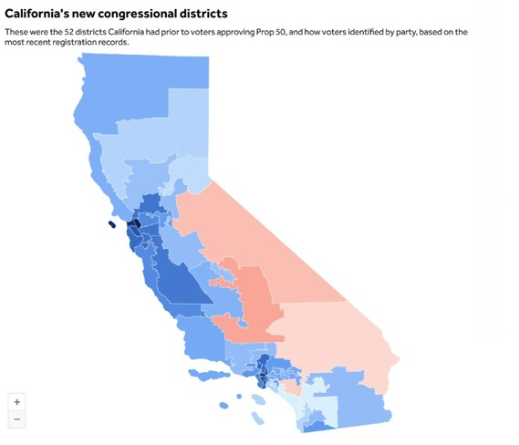

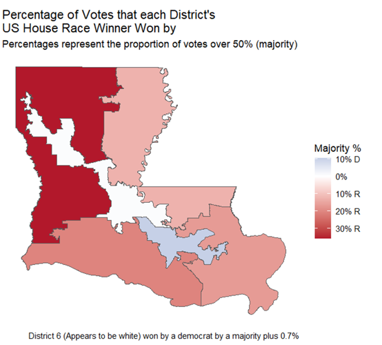

Louisiana 2024 Map

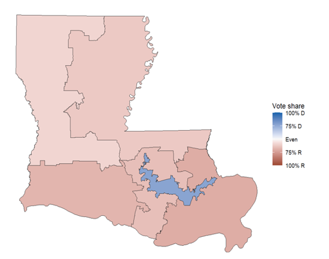

Louisiana 2020 Map

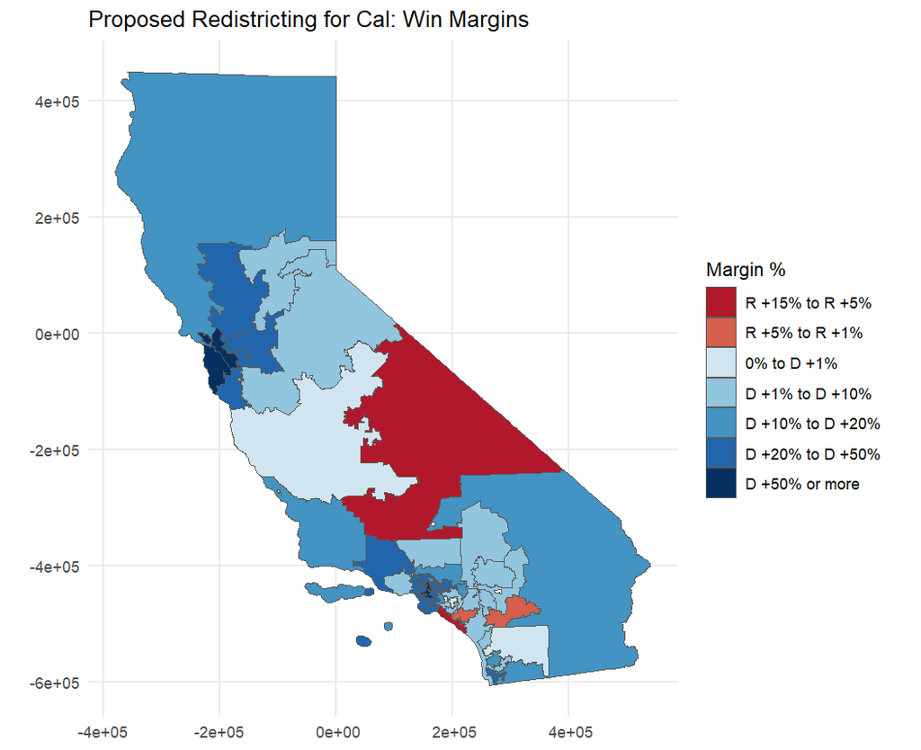

# References Kantas, N., Doucet, A., Singh, S. S., & Maciejowski, J. M. (2009). An Overview of Sequential Monte Carlo Methods for Parameter Estimation in General State-Space Models. IFAC Proceedings Volumes, 42(10), 774–785. https://doi.org/10.3182/20090706-3-fr-2004.00129

Redistricting Data Hub. (n.d.). Redistricting Data Hub. https://redistrictingdatahub.org/

Redistricting in California ahead of the 2026 elections. (2026). Ballotpedia. https://ballotpedia.org/Redistricting_in_California_ahead_of_the_2026_elections

Redistricting Report Card. (2023). Gerrymander.princeton.edu. https://gerrymander.princeton.edu/redistricting-report-card

The Latest on Mid-Decade Redistricting: California Update. (2026, April 27). Common Cause California. https://www.commoncause.org/california/resources/the-latest-on-mid-decade-redistricting-california-update/

…